# Elective Project: Pratical Data Science - Potential Customers Prediction

##### Author: Charlotte Bredy-Maux

##### Created on: January, 27th 2024

##### Last Modified on: January, 27th 2024

### Problem Statement Key-Points

The education market is markedly changing and growing in demand in the Online Education sector. The supply side is thus incentivized to increase its investment in market research and analysis in order to improve its customer targeting strategy.

Additionaly, companies need to take into account that they interact with two-sided markets through social media marketing and highly rely on so-called leads customers.

**The goals are to:**

1. Perform customer analysis i.e., EDA
2. Build an ML model that predicts the probability for a given lead to be converted into a paid customer i.e., classify leads into future paid customers and non-customers
3. Socio-economically and demographically identify leads classified as future customers

We present this Conversion Rate Optimization project following the above sections.

## 0. Install packages, import libraries and dataset

```python
# Import the librairies for data pre-processing, data visualization and exploratory data analysis
import pandas as pd
import numpy as np
import matplotlib.pyplot as plt
import seaborn as sns
from sklearn.mixture import GaussianMixture
from scipy.stats import norm
from sklearn.linear_model import LogisticRegression
from sklearn.preprocessing import PolynomialFeatures
from sklearn.pipeline import make_pipeline
import statsmodels.api as sm
from sklearn.feature_selection import mutual_info_regression
from sklearn.neighbors import KernelDensity
import sklearn_extra
from sklearn_extra.cluster import KMedoids
from sklearn.model_selection import train_test_split, cross_val_score, KFold, GridSearchCV
from sklearn.preprocessing import StandardScaler
from concurrent.futures import ProcessPoolExecutor
from sklearn.linear_model import LinearRegression, Ridge, Lasso, ElasticNet
from sklearn.tree import DecisionTreeClassifier
from sklearn.ensemble import RandomForestClassifier, BaggingClassifier, AdaBoostClassifier, GradientBoostingClassifier
from xgboost import XGBRFClassifier
from sklearn.metrics import mean_squared_error, r2_score, mean_absolute_error, accuracy_score, precision_score, recall_score, f1_score, confusion_matrix, make_scorer, silhouette_score
from tensorflow.keras.models import Sequential
from tensorflow.keras.layers import Dense, Dropout, BatchNormalization
from tensorflow.keras.optimizers import Adam
from tensorflow.keras.callbacks import EarlyStopping
from keras.regularizers import l2
from tensorflow.keras.optimizers import schedules
from sklearn.metrics import accuracy_score
from sklearn import tree
```

```python
# Load data into a DataFrame
data_path = 'ExtraaLearn.csv'
df = pd.read_csv(data_path)

# Display the first few rows of the DataFrame
print("First few rows of the data:")
print(df.head())

# Check the data types and missing values
print("\nData types and missing values:")
print(df.info())
```

```
First few rows of the data:
       ID  age current_occupation first_interaction profile_completed  \
0  EXT001   57         Unemployed           Website              High
1  EXT002   56       Professional        Mobile App            Medium
2  EXT003   52       Professional           Website            Medium
3  EXT004   53         Unemployed           Website              High
4  EXT005   23            Student           Website              High

   website_visits  time_spent_on_website  page_views_per_visit  \
0               7                   1639                 1.861
1               2                     83                 0.320
2               3                    330                 0.074
3               4                    464                 2.057
4               4                    600                16.914

      last_activity print_media_type1 print_media_type2 digital_media  \
0  Website Activity               Yes                No           Yes
1  Website Activity                No                No            No
2  Website Activity                No                No           Yes
3  Website Activity                No                No            No
4    Email Activity                No                No            No

  educational_channels referral  status
0                   No       No       1
1                  Yes       No       0
2                   No       No       0
3                   No       No       1
4                   No       No       0

Data types and missing values:
<class 'pandas.core.frame.DataFrame'>
RangeIndex: 4612 entries, 0 to 4611
Data columns (total 15 columns):
 #   Column                 Non-Null Count  Dtype
---  ------                 --------------  -----
 0   ID                     4612 non-null   object
 1   age                    4612 non-null   int64
 2   current_occupation     4612 non-null   object
 3   first_interaction      4612 non-null   object
 4   profile_completed      4612 non-null   object
 5   website_visits         4612 non-null   int64
 6   time_spent_on_website  4612 non-null   int64
 7   page_views_per_visit   4612 non-null   float64
 8   last_activity          4612 non-null   object
 9   print_media_type1      4612 non-null   object
 10  print_media_type2      4612 non-null   object
 11  digital_media          4612 non-null   object
 12  educational_channels   4612 non-null   object
 13  referral               4612 non-null   object
 14  status                 4612 non-null   int64
dtypes: float64(1), int64(4), object(10)
memory usage: 540.6+ KB
None
```

```python
df
```

|  | ID | age | current_occupation | first_interaction | profile_completed | website_visits | time_spent_on_website | page_views_per_visit | last_activity | print_media_type1 | print_media_type2 | digital_media | educational_channels | referral | status |
| --- | --- | --- | --- | --- | --- | --- | --- | --- | --- | --- | --- | --- | --- | --- | --- |
| 0 | EXT001 | 57 | Unemployed | Website | High | 7 | 1639 | 1.861 | Website Activity | Yes | No | Yes | No | No | 1 |
| 1 | EXT002 | 56 | Professional | Mobile App | Medium | 2 | 83 | 0.320 | Website Activity | No | No | No | Yes | No | 0 |
| 2 | EXT003 | 52 | Professional | Website | Medium | 3 | 330 | 0.074 | Website Activity | No | No | Yes | No | No | 0 |
| 3 | EXT004 | 53 | Unemployed | Website | High | 4 | 464 | 2.057 | Website Activity | No | No | No | No | No | 1 |
| 4 | EXT005 | 23 | Student | Website | High | 4 | 600 | 16.914 | Email Activity | No | No | No | No | No | 0 |
| ... | ... | ... | ... | ... | ... | ... | ... | ... | ... | ... | ... | ... | ... | ... | ... |
| 4607 | EXT4608 | 35 | Unemployed | Mobile App | Medium | 15 | 360 | 2.170 | Phone Activity | No | No | No | Yes | No | 0 |
| 4608 | EXT4609 | 55 | Professional | Mobile App | Medium | 8 | 2327 | 5.393 | Email Activity | No | No | No | No | No | 0 |
| 4609 | EXT4610 | 58 | Professional | Website | High | 2 | 212 | 2.692 | Email Activity | No | No | No | No | No | 1 |
| 4610 | EXT4611 | 57 | Professional | Mobile App | Medium | 1 | 154 | 3.879 | Website Activity | Yes | No | No | No | No | 0 |
| 4611 | EXT4612 | 55 | Professional | Website | Medium | 4 | 2290 | 2.075 | Phone Activity | No | No | No | No | No | 0 |

4612 rows × 15 columns

### **General Description of the Dataset**

The dataset displays 4612 rows i.e., 4612 leads and 15 columns (1 ID, 13 predictors and one target).

#### Data Types and Missing Values

Overall, the categorical variables and are stored as object. 'Status' is stored as an integer even though it is a categorical variable i.e., dummy. There are no missing values.

1. The dataset includes **general information** about the lead:
- their age
- they current occupation
- the type of their first interaction with ExtraaLearn
- the percentage of completed profile on a website or mobile application
1. The dataset also includes specific **website-related information:**
- the number of visits
- the total time spent
- the average number of pages viewed
- the type of the last activity with a representative on the website
- the last interaction between the lead and ExtraaLearn
1. The dataset also includes specific **media-related information:**
- whether the lead had seen an ad in the newspapper
- whether the lead had seen an ad in the magazine
- whether the lead had seen an ad on digital platforms
- whether the lead had seen an ad in educational channel
1. The dataset also includes specific **direct communication-related information:**
- the type of activity on the phone with a representative
- whether the lead had heard about ExtraaLearn through reference
1. The **target variable**:
- whether the lead was converted to a paid customer or not

*Disclaimer: at the date of creation of the project, the columns last_activity, Email Activity and Phone Activity were missing from the dataset*

## 1. EDA

### Linear Univariate Analysis

```
Summary statistics for age:
count    4612.000000
mean       46.201214
std        13.161454
min        18.000000
25%        36.000000
50%        51.000000
75%        57.000000
max        63.000000
Name: age, dtype: float64
```

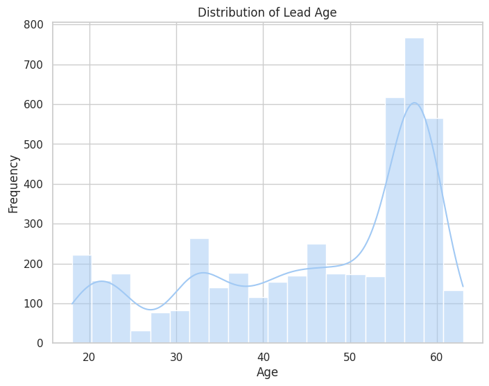

```python
# Analyze the distribution of age
print("Summary statistics for age:")
print(df['age'].describe())

# Visualize the distribution
sns.set_theme(style="whitegrid", palette="pastel")
plt.figure(figsize=(8, 6))
sns.histplot(df['age'], bins=20, kde=True)
plt.title('Distribution of Lead Age')
plt.xlabel('Age')
plt.ylabel('Frequency')
plt.show()
```

```python
df[df['age'] > 50]
```

|  | ID | age | current_occupation | first_interaction | profile_completed | website_visits | time_spent_on_website | page_views_per_visit | last_activity | print_media_type1 | print_media_type2 | digital_media | educational_channels | referral | status |
| --- | --- | --- | --- | --- | --- | --- | --- | --- | --- | --- | --- | --- | --- | --- | --- |
| 0 | EXT001 | 57 | Unemployed | Website | High | 7 | 1639 | 1.861 | Website Activity | Yes | No | Yes | No | No | 1 |
| 1 | EXT002 | 56 | Professional | Mobile App | Medium | 2 | 83 | 0.320 | Website Activity | No | No | No | Yes | No | 0 |
| 2 | EXT003 | 52 | Professional | Website | Medium | 3 | 330 | 0.074 | Website Activity | No | No | Yes | No | No | 0 |
| 3 | EXT004 | 53 | Unemployed | Website | High | 4 | 464 | 2.057 | Website Activity | No | No | No | No | No | 1 |
| 6 | EXT007 | 56 | Professional | Mobile App | Medium | 13 | 625 | 2.015 | Website Activity | No | No | Yes | No | No | 1 |
| ... | ... | ... | ... | ... | ... | ... | ... | ... | ... | ... | ... | ... | ... | ... | ... |
| 4606 | EXT4607 | 58 | Unemployed | Mobile App | High | 7 | 210 | 3.598 | Email Activity | No | No | No | No | No | 0 |
| 4608 | EXT4609 | 55 | Professional | Mobile App | Medium | 8 | 2327 | 5.393 | Email Activity | No | No | No | No | No | 0 |
| 4609 | EXT4610 | 58 | Professional | Website | High | 2 | 212 | 2.692 | Email Activity | No | No | No | No | No | 1 |
| 4610 | EXT4611 | 57 | Professional | Mobile App | Medium | 1 | 154 | 3.879 | Website Activity | Yes | No | No | No | No | 0 |
| 4611 | EXT4612 | 55 | Professional | Website | Medium | 4 | 2290 | 2.075 | Phone Activity | No | No | No | No | No | 0 |

2340 rows × 15 columns

The most common profile of a lead is a professional, who interacted first with the company via a website, with a complete profile, who last interacted via emails and who has not seen any ad, nor has learnt about the company by someone else.

```
Descriptive Statistics for Categorical Variables:
            ID current_occupation first_interaction profile_completed  \
count     4612               4612              4612              4612
unique    4612                  3                 2                 3
top     EXT001       Professional           Website              High
freq         1               2616              2542              2264

         last_activity print_media_type1 print_media_type2 digital_media  \
count             4612              4612              4612          4612
unique               3                 2                 2             2
top     Email Activity                No                No            No
freq              2278              4115              4379          4085

       educational_channels referral
count                  4612     4612
unique                    2        2
top                      No       No
freq                   3907     4519
```

[figure not shown]

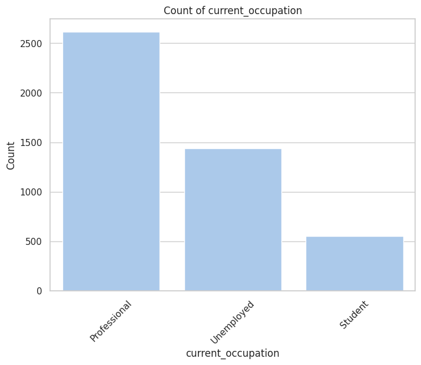

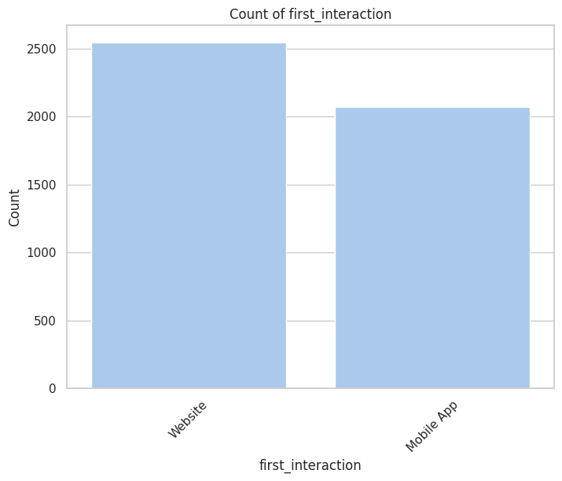

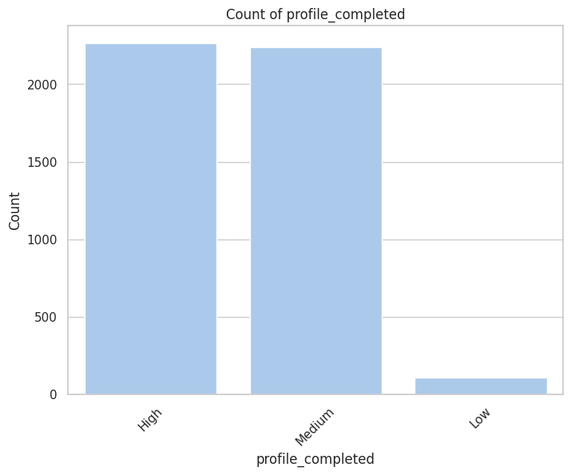

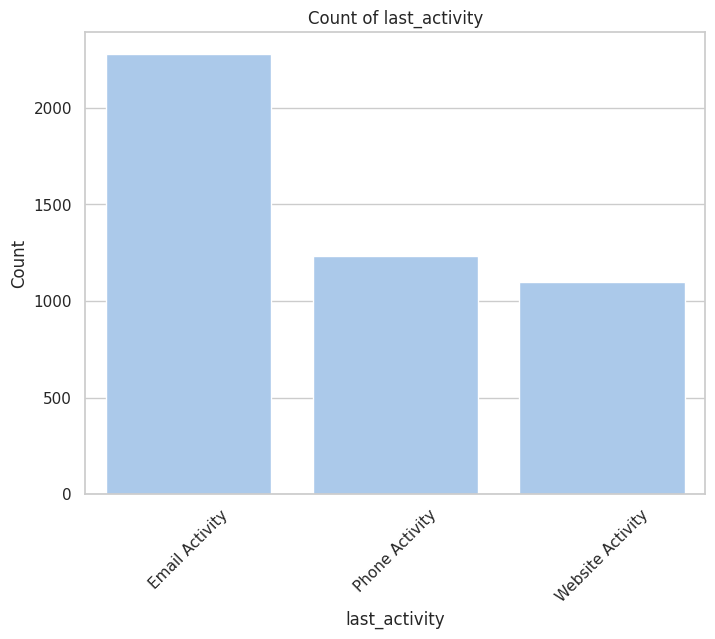

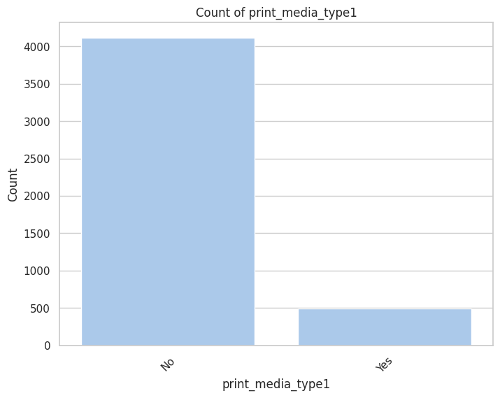

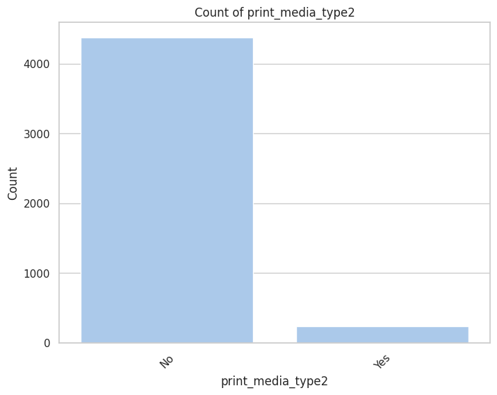

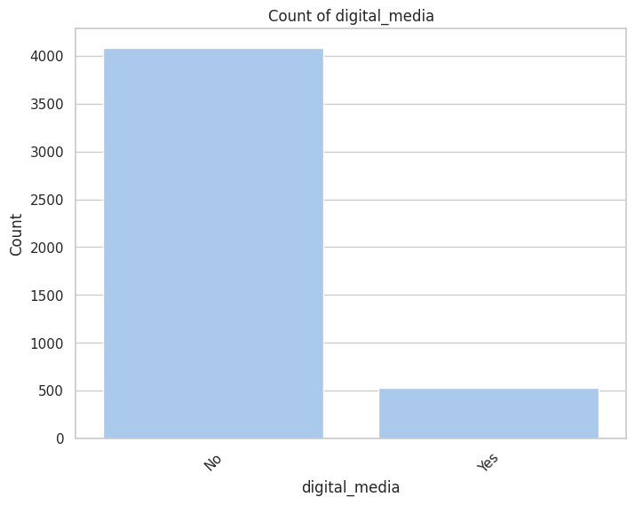

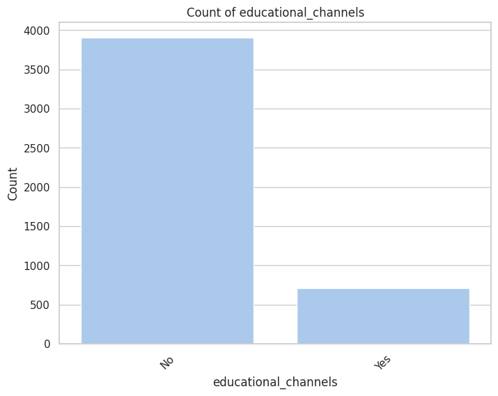

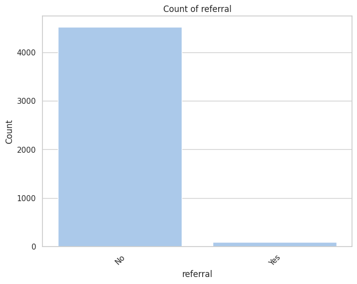

```python
# Descriptive Statistics for Categorical Variables
categorical_columns = df.select_dtypes(include=['object']).columns  # Select categorical columns
categorical_summary = df[categorical_columns].describe()  # Generate descriptive statistics
print("Descriptive Statistics for Categorical Variables:")
print(categorical_summary)

# Data Visualization for Categorical Variables
for column in categorical_columns:
    plt.figure(figsize=(8, 6))
    sns.countplot(data=df, x=column, order=df[column].value_counts().index)
    plt.title(f'Count of {column}')
    plt.xlabel(column)
    plt.ylabel('Count')
    plt.xticks(rotation=45)
    plt.show()
```

```
Descriptive Statistics for Categorical Variables:
            ID current_occupation first_interaction profile_completed  \
count     2340               2340              2340              2340
unique    2340                  2                 2                 3
top     EXT001       Professional           Website              High
freq         1               1513              1297              1171

         last_activity print_media_type1 print_media_type2 digital_media  \
count             2340              2340              2340          2340
unique               3                 2                 2             2
top     Email Activity                No                No            No
freq              1169              2081              2219          2061

       educational_channels referral
count                  2340     2340
unique                    2        2
top                      No       No
freq                   1996     2291
```

[figure not shown]

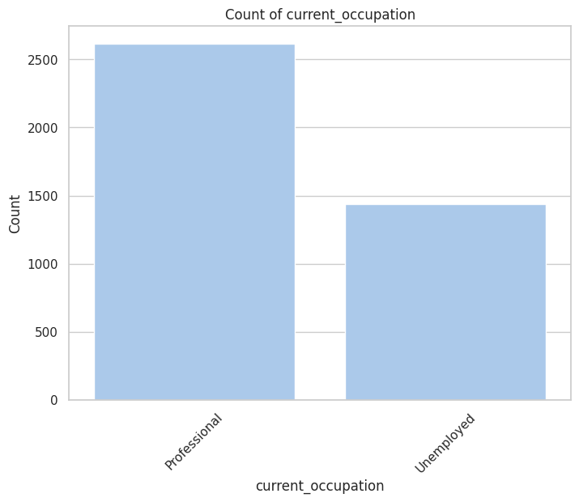

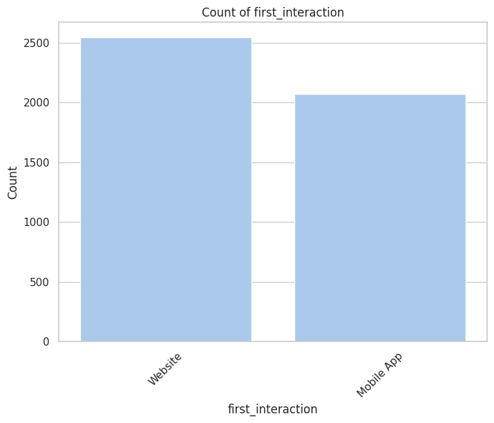

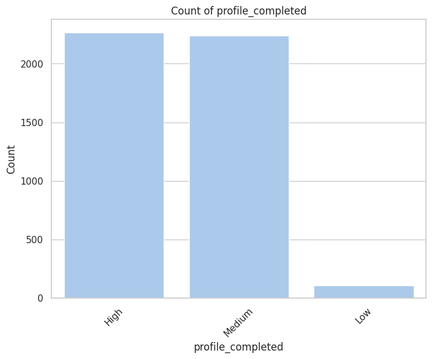

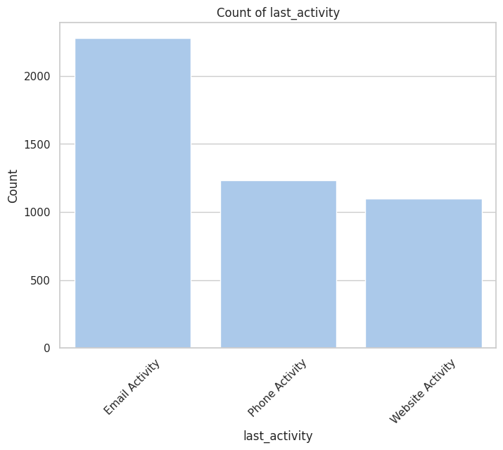

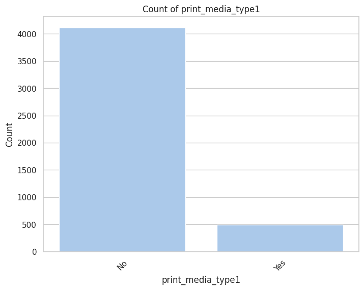

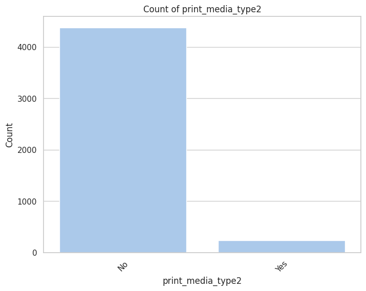

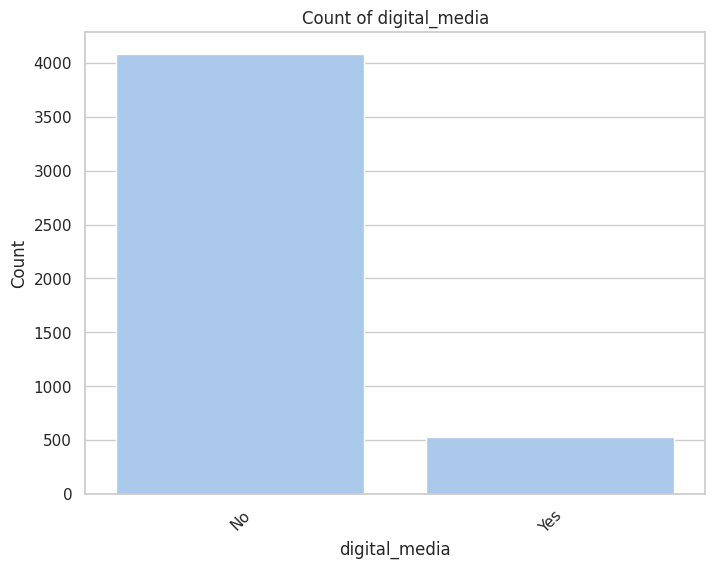

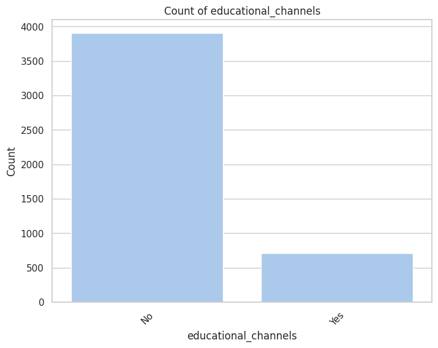

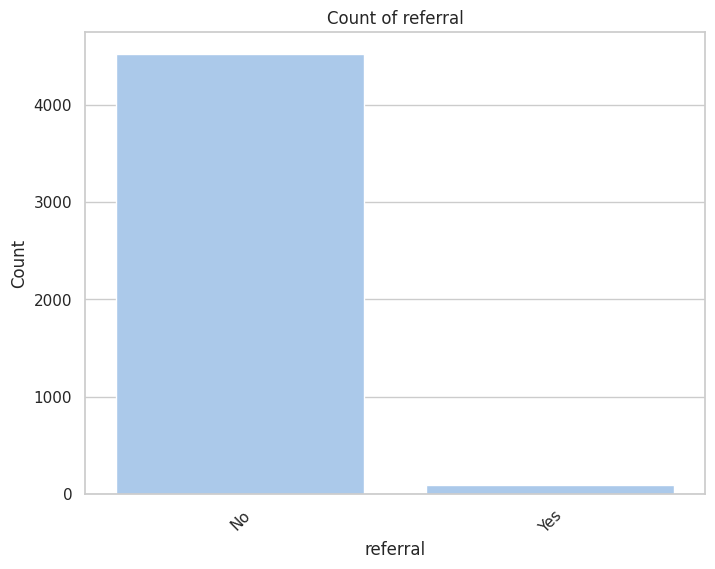

```python
# Descriptive Statistics for Categorical Variables
categorical_columns = df[df['age'] > 50].select_dtypes(include=['object']).columns  # Select categorical columns
categorical_summary = df[df['age'] > 50][categorical_columns].describe()  # Generate descriptive statistics
print("Descriptive Statistics for Categorical Variables:")
print(categorical_summary)

# Data Visualization for Categorical Variables
for column in categorical_columns:
    plt.figure(figsize=(8, 6))
    sns.countplot(data=df, x=column, order=df[df['age'] > 50][column].value_counts().index)
    plt.title(f'Count of {column}')
    plt.xlabel(column)
    plt.ylabel('Count')
    plt.xticks(rotation=45)
    plt.show()
```

```
Summary statistics for the number of website visits:
count    4612.000000
mean        3.566782
std         2.829134
min         0.000000
25%         2.000000
50%         3.000000
75%         5.000000
max        30.000000
Name: website_visits, dtype: float64
```

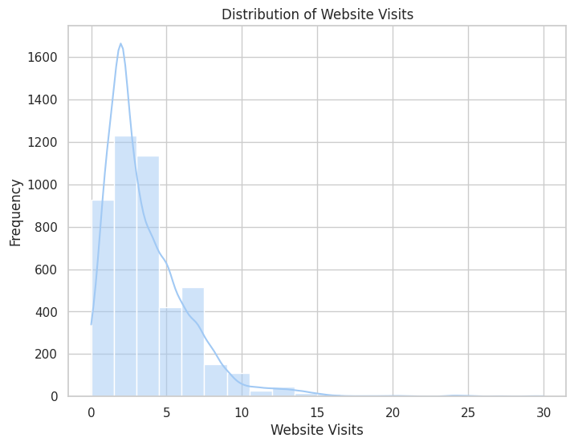

```python
# Analyze the distribution of age
print("Summary statistics for the number of website visits:")
print(df['website_visits'].describe())

# Visualize the distribution
sns.set_theme(style="whitegrid", palette="pastel")
plt.figure(figsize=(8, 6))
sns.histplot(df['website_visits'], bins=20, kde=True)
plt.title('Distribution of Website Visits')
plt.xlabel('Website Visits')
plt.ylabel('Frequency')
plt.show()
```

Leads visit the website between 3 and 5 times on average. An outlier visited it 30 times.

```python
df[df["website_visits"]==30]
```

|  | ID | age | current_occupation | first_interaction | profile_completed | website_visits | time_spent_on_website | page_views_per_visit | last_activity | print_media_type1 | print_media_type2 | digital_media | educational_channels | referral | status |
| --- | --- | --- | --- | --- | --- | --- | --- | --- | --- | --- | --- | --- | --- | --- | --- |
| 509 | EXT510 | 24 | Student | Mobile App | Medium | 30 | 388 | 3.566 | Website Activity | No | No | No | No | No | 0 |

This lead is 24 years-old student who typically interacted with the company via the mobile app. There is probably a demographical opportunity given the fact that most people under 30 use their phone and apps to access information.

As a first trail of recommendation, the company could invest in improving or updating its mobile app to attract more student and people under 30 years-old in general.

```
Summary statistics for the number of website visits:
count    4612.000000
mean      724.011275
std       743.828683
min         0.000000
25%       148.750000
50%       376.000000
75%      1336.750000
max      2537.000000
Name: time_spent_on_website, dtype: float64
```

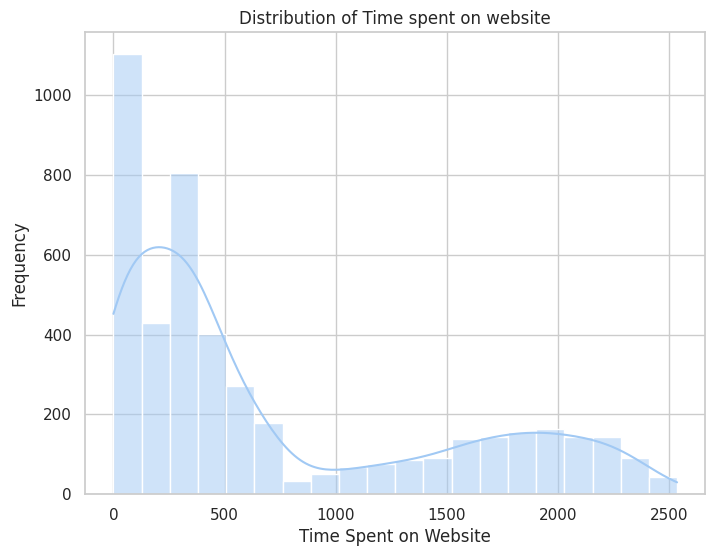

```python
# Analyze the distribution of age
print("Summary statistics for the number of website visits:")
print(df['time_spent_on_website'].describe())

# Visualize the distribution
sns.set_theme(style="whitegrid", palette="pastel")
plt.figure(figsize=(8, 6))
sns.histplot(df['time_spent_on_website'], bins=20, kde=True)
plt.title('Distribution of Time spent on website')
plt.xlabel('Time Spent on Website')
plt.ylabel('Frequency')
plt.show()
```

Leads spent on average 724 minutes on the website but that number is not very descriptive of the actual distribution and patterns in the data. Indeed, a first group of leads spend less than 500 minutes on the website, and another group spend about 2000 minutes on average. We further explore the bi-modality of the distribution of time spent on website.

Specifically, we use a Gaussian Mixture Models (GMMs) to fit a mixture of Gaussian distributions to the data and determine whether it comes from a single distribution or multiple distributions. GMMs are a probabilistic model commonly used for clustering and density estimation tasks, including identifying subpopulations within a dataset.

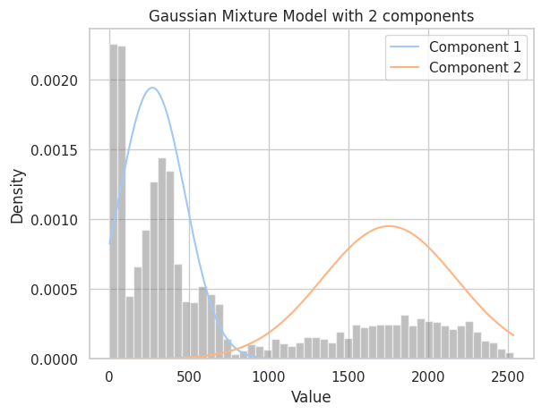

```python
# Extract the column containing our time data
data = df['time_spent_on_website']

# Fit Gaussian Mixture Model with different number of components
n_components = np.arange(1, 3)
models = [GaussianMixture(n, covariance_type='full', random_state=0).fit(data.values.reshape(-1, 1)) for n in n_components]
bic_scores = [model.bic(data.values.reshape(-1, 1)) for model in models]

# Determine the optimal number of components using the Bayesian Information Criterion (BIC)
optimal_n_components = n_components[np.argmin(bic_scores)]

# Fit GMM with the optimal number of components
gmm = GaussianMixture(n_components=optimal_n_components, covariance_type='full', random_state=0)
gmm.fit(data.values.reshape(-1, 1))

# Plot histogram of the data
plt.hist(data, bins=50, density=True, alpha=0.5, color='gray')

# Plot each component of the GMM
x = np.linspace(data.min(), data.max(), 1000)
for i in range(optimal_n_components):
    y = norm.pdf(x, gmm.means_[i, 0], np.sqrt(gmm.covariances_[i, 0, 0]))
    plt.plot(x, y, label=f'Component {i+1}')

plt.legend()
plt.title(f'Gaussian Mixture Model with {optimal_n_components} components')
plt.xlabel('Value')
plt.ylabel('Density')
plt.show()
```

### Linear Multivariate Analysis

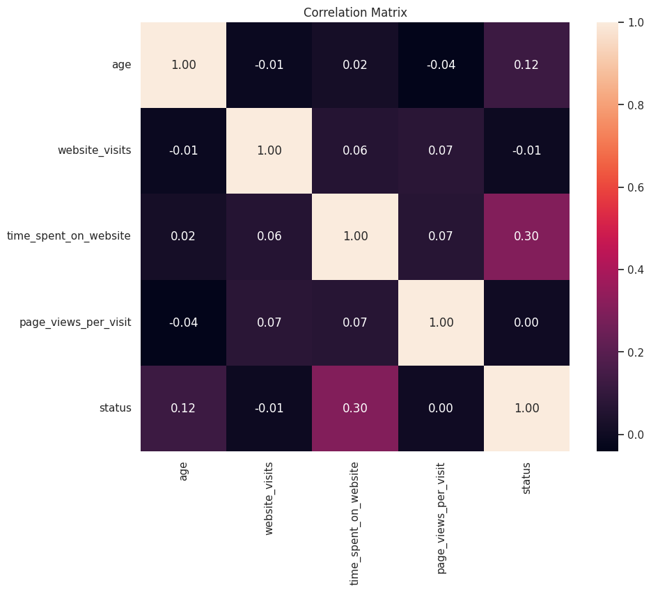

```python
# Compute the correlation matrix
correlation_matrix = df.corr()

# Plot the correlation matrix using seaborn
plt.figure(figsize=(10, 8))
sns.heatmap(correlation_matrix, annot=True, fmt=".2f", square=True)
plt.title('Correlation Matrix')
plt.show()
```

```
Optimization terminated successfully.
         Current function value: 0.491245
         Iterations 5
```

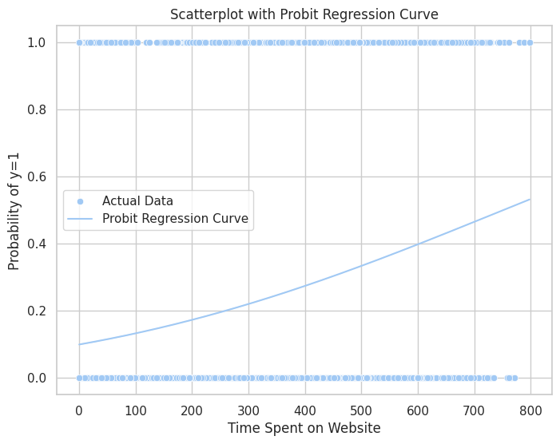

```python
# Modelling time spent on website for the first distribution i.e., time < 800
x = df[df['time_spent_on_website'] < 800]['time_spent_on_website'].values
y = (df[df['time_spent_on_website'] < 800]['status'] == 1).astype(int)

# Fit probit regression model
x_with_const = sm.add_constant(x)
model = sm.Probit(y, x_with_const)
result = model.fit()

# Predict probabilities
x_pred = np.linspace(x.min(), x.max(), 1000)
x_pred_with_const = sm.add_constant(x_pred)
y_prob = result.predict(x_pred_with_const)

# Create DataFrame for plotting
plot_data = pd.DataFrame({'x': x, 'y': y, 'Probability': result.predict(x_with_const)})

# Plot the scatterplot and probit regression curve using Seaborn
plt.figure(figsize=(8, 6))
sns.scatterplot(data=plot_data, x='x', y='y', label='Actual Data')
sns.lineplot(data=plot_data, x='x', y='Probability', label='Probit Regression Curve')
plt.title('Scatterplot with Probit Regression Curve')
plt.xlabel('Time Spent on Website')
plt.ylabel('Probability of y=1')
plt.legend()
plt.grid(True)
plt.show()
```

```python
# Print the summary of the model
print(result.summary())
```

```
                          Probit Regression Results
==============================================================================
Dep. Variable:                 status   No. Observations:                 3196
Model:                         Probit   Df Residuals:                     3194
Method:                           MLE   Df Model:                            1
Date:                Tue, 30 Jan 2024   Pseudo R-squ.:                 0.05904
Time:                        14:26:34   Log-Likelihood:                -1570.0
converged:                       True   LL-Null:                       -1668.5
Covariance Type:            nonrobust   LLR p-value:                 9.381e-45
==============================================================================
                 coef    std err          z      P>|z|      [0.025      0.975]
------------------------------------------------------------------------------
const         -1.2836      0.045    -28.336      0.000      -1.372      -1.195
x1             0.0017      0.000     13.821      0.000       0.001       0.002
==============================================================================
```

The probit model significantly explains how the likelihood of becoming a customer increases with time spent on the website, when time not exceed 800 minutes.

```
Optimization terminated successfully.
         Current function value: 0.691424
         Iterations 3
```

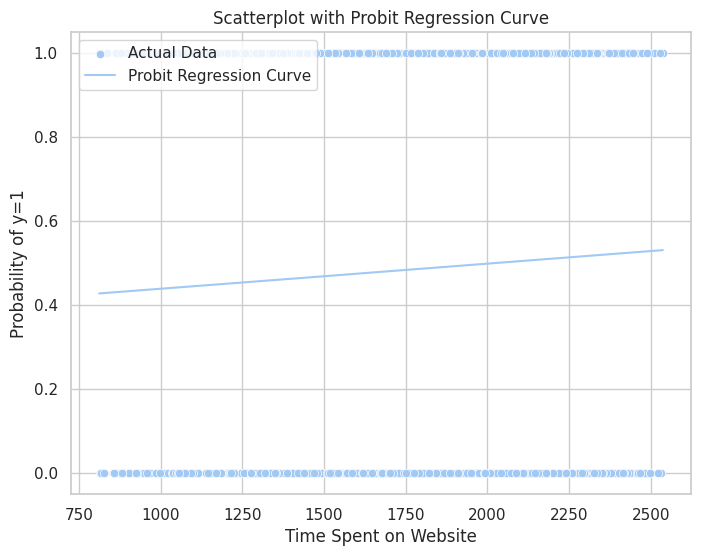

```python
# Modelling time spent on website for the first distribution i.e., time < 800
x = df[df['time_spent_on_website'] > 800]['time_spent_on_website'].values
y = (df[df['time_spent_on_website'] > 800]['status'] == 1).astype(int)

# Fit probit regression model
x_with_const = sm.add_constant(x)
model = sm.Probit(y, x_with_const)
result = model.fit()

# Predict probabilities
x_pred = np.linspace(x.min(), x.max(), 1000)
x_pred_with_const = sm.add_constant(x_pred)
y_prob = result.predict(x_pred_with_const)

# Create DataFrame for plotting
plot_data = pd.DataFrame({'x': x, 'y': y, 'Probability': result.predict(x_with_const)})

# Plot the scatterplot and probit regression curve using Seaborn
plt.figure(figsize=(8, 6))
sns.scatterplot(data=plot_data, x='x', y='y', label='Actual Data')
sns.lineplot(data=plot_data, x='x', y='Probability', label='Probit Regression Curve')
plt.title('Scatterplot with Probit Regression Curve')
plt.xlabel('Time Spent on Website')
plt.ylabel('Probability of y=1')
plt.legend()
plt.grid(True)
plt.show()
```

```python
# Print the summary of the model
print(result.summary())
```

```
                          Probit Regression Results
==============================================================================
Dep. Variable:                 status   No. Observations:                 1416
Model:                         Probit   Df Residuals:                     1414
Method:                           MLE   Df Model:                            1
Date:                Tue, 30 Jan 2024   Pseudo R-squ.:                0.001791
Time:                        14:26:41   Log-Likelihood:                -979.06
converged:                       True   LL-Null:                       -980.81
Covariance Type:            nonrobust   LLR p-value:                   0.06090
==============================================================================
                 coef    std err          z      P>|z|      [0.025      0.975]
------------------------------------------------------------------------------
const         -0.3034      0.145     -2.091      0.036      -0.588      -0.019
x1             0.0002   8.03e-05      1.873      0.061   -6.96e-06       0.000
==============================================================================
```

Interestingly, we observe that the likelihood of becoming a customer increases less rapidly with time spent on the website when time exceeds 800 minutes. There is an attrition effect and, in addition to optimizing the app to attract more customer under 30 years old, the company should also optimize its website in order for the visitors to find all information under 800 minutes maximum, and thuslz maximize the likelihood of conversion.

### Non Linear Analysis

We explore the following technique:

**Mutual Information**

Mutual Information measures the amount of information that knowing the value of one variable provides about another variable. It can capture both linear and non-linear dependencies.

#### Mututal Information

Mutual information is a measure of the amount of information one random variable contains about another random variable. It is used to quantify the dependence between the two variables. The formula for mutual information

$$I(X;Y)$$

between two discrete random variables $$X$$ and $$Y$$ is given by:

$$ I(X;Y)=\int_{y ∈ Y} \int_{x ∈ X} p(x,y) . log(\frac{p(x,y)}{p(x)p(y)}) dx dy)$$

where:

$p(x,y)$ is the joint probability mass function of $X$ and $Y$,

$p(x)$ is the marginal probability mass function of $X$,

$p(y)$ is the marginal probability mass function of $Y$.

*Important Note*

In the context of feature selection and mutual information regression, the mutual information between a feature and the target variable is calculated to estimate the information gain about the target provided by that feature.

It's important to note that mutual information is a symmetric measure, meaning

$$ I(X;Y)=I(Y;X) $$

. Also, it is non-negative, and higher values indicate stronger dependencies between the variables.

The concept of mutual information is related to, but distinct from, Fisher information. Fisher information is a concept from statistics used in the context of estimating parameters in a statistical model. It is related to the variance of the score function (derivative of the log-likelihood function) with respect to the parameter. While both mutual information and Fisher information involve the concept of information, they serve different purposes and are applied in different contexts within statistics and information theory.

In practice, when estimating mutual information from data, you might use kernel density estimation (KDE) or other methods to approximate the probability density functions. The goal is to estimate the joint and marginal distributions from the observed data and then apply the mutual information formula.

```python
# Identify numerical columns
numerical_columns = df.select_dtypes(include=['int', 'float']).columns

# Select the target variable
y = df["status"]

# Initialize an empty dictionary to store KDE models for each numerical feature
kde_models = {}

# Fit KDE models for each numerical feature
for column in numerical_columns:
    kde = KernelDensity(bandwidth=1.0, kernel='gaussian')  # You can adjust the bandwidth and kernel as needed
    kde.fit(df[column].values.reshape(-1, 1))
    kde_models[column] = kde

# Calculate mutual information using KDE-based PDFs
mutual_info_scores = {}
for column in numerical_columns:
    kde = kde_models[column]
    log_density_x = kde.score_samples(df[column].values.reshape(-1, 1))
    log_density_y = kde.score_samples(y.values.reshape(-1, 1))
    mi = np.mean(log_density_x + log_density_y - kde.score_samples(df[column].values.reshape(-1, 1)))
    mutual_info_scores[column] = mi

# Display mutual information scores
print("Mutual Information Scores:")
print(mutual_info_scores)
```

```
Mutual Information Scores:
{'age': -161.94074402054937, 'website_visits': -2.4411362252046316, 'time_spent_on_website': -4.031832578410107, 'page_views_per_visit': -2.493606427163135, 'status': -1.1030207801375402}
```

The negative MI values indicate that the joint information shared between variables is less than the information contained in the product of their marginal distributions. In other words, knowing one variable provides less information about the other variable than would be expected if they were independent. However, the relative difference in MI values between different pairs of variables is still informative.

When comparing MI values across different pairs of variables, the relative differences are often more informative than the absolute values themselves. Negative MI values may still indicate meaningful relationships or dependencies between variables, especially when comparing them within the same dataset or analysis.

We see in particular that age contains way more information about status than the other variable in absolute value.

#### Clustering

```python
df.select_dtypes(include=['int', 'float'])
```

|  | age | website_visits | time_spent_on_website | page_views_per_visit | status |
| --- | --- | --- | --- | --- | --- |
| 0 | 57 | 7 | 1639 | 1.861 | 1 |
| 1 | 56 | 2 | 83 | 0.320 | 0 |
| 2 | 52 | 3 | 330 | 0.074 | 0 |
| 3 | 53 | 4 | 464 | 2.057 | 1 |
| 4 | 23 | 4 | 600 | 16.914 | 0 |
| ... | ... | ... | ... | ... | ... |
| 4607 | 35 | 15 | 360 | 2.170 | 0 |
| 4608 | 55 | 8 | 2327 | 5.393 | 0 |
| 4609 | 58 | 2 | 212 | 2.692 | 1 |
| 4610 | 57 | 1 | 154 | 3.879 | 0 |
| 4611 | 55 | 4 | 2290 | 2.075 | 0 |

4612 rows × 5 columns

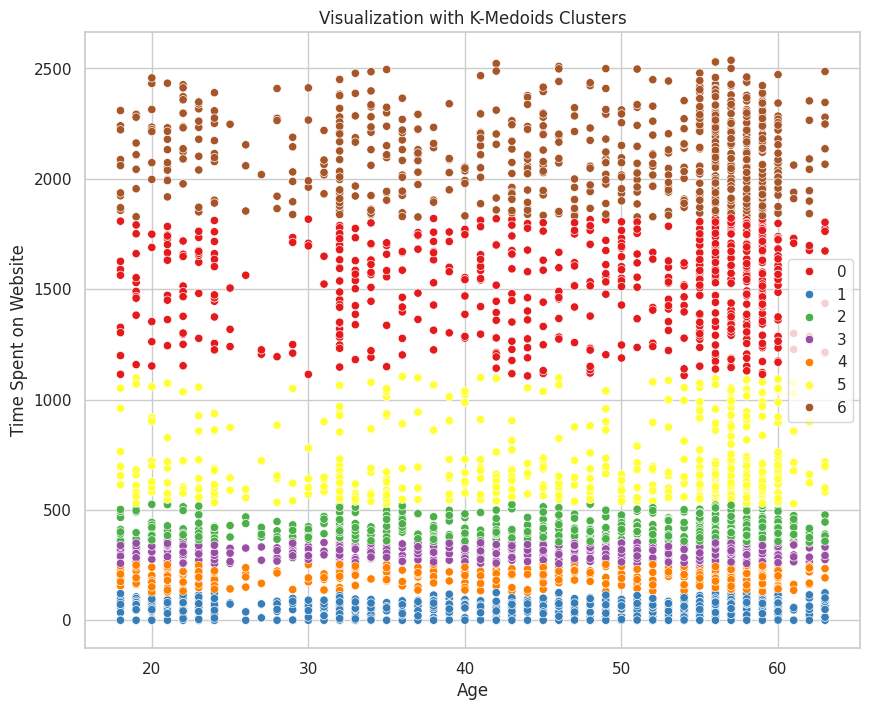

```python
# Specify the number of clusters
num_clusters = 7


# Select numerical columns for clustering
numerical_columns = df.select_dtypes(include=['int', 'float'])

# Initialize K-Medoids model
kmedoids = KMedoids(n_clusters=num_clusters, random_state=42)

# Fit K-Medoids model
cluster_assignments = kmedoids.fit_predict(numerical_columns)

# Visualize clustering results
plt.figure(figsize=(10, 8))
sns.scatterplot(x=numerical_columns.iloc[:, 0], y=numerical_columns.iloc[:, 2], hue=cluster_assignments, palette='Set1', legend='full')

# Set labels and title
plt.xlabel('Age')
plt.ylabel('Time Spent on Website')
plt.title('Visualization with K-Medoids Clusters')

# Show the plot
plt.show()
```

We see that age and time spent on website stratify the data. Duration under 500 minutes encompass 4 clusters out of 7, across the entire age spectrum.

## 2. Classification

### Train Test Split

```python
# Split the data into training and test sets without sharing common 'ID'
train_ids, test_ids = train_test_split(df["ID"].unique(), test_size=0.3, shuffle=True)

# Build X features sets
X_train = df[df["ID"].isin(train_ids)].drop(columns=["status", "ID"])
y_train = df[df["ID"].isin(train_ids)]["status"]

X_test = df[df["ID"].isin(test_ids)].drop(columns=["status", "ID"])
y_test = df[df["ID"].isin(test_ids)]["status"]

# Perform one-hot encoding for categorical columns
X_train_encoded = pd.get_dummies(X_train, drop_first=True)
X_test_encoded = pd.get_dummies(X_test, drop_first=True)
X_train = X_train_encoded
X_test = X_test_encoded
```

```python
X_train
```

|  | age | website_visits | time_spent_on_website | page_views_per_visit | current_occupation_Student | current_occupation_Unemployed | first_interaction_Website | profile_completed_Low | profile_completed_Medium | last_activity_Phone Activity | last_activity_Website Activity | print_media_type1_Yes | print_media_type2_Yes | digital_media_Yes | educational_channels_Yes | referral_Yes |
| --- | --- | --- | --- | --- | --- | --- | --- | --- | --- | --- | --- | --- | --- | --- | --- | --- |
| 0 | 57 | 7 | 1639 | 1.861 | 0 | 1 | 1 | 0 | 0 | 0 | 1 | 1 | 0 | 1 | 0 | 0 |
| 1 | 56 | 2 | 83 | 0.320 | 0 | 0 | 0 | 0 | 1 | 0 | 1 | 0 | 0 | 0 | 1 | 0 |
| 2 | 52 | 3 | 330 | 0.074 | 0 | 0 | 1 | 0 | 1 | 0 | 1 | 0 | 0 | 1 | 0 | 0 |
| 3 | 53 | 4 | 464 | 2.057 | 0 | 1 | 1 | 0 | 0 | 0 | 1 | 0 | 0 | 0 | 0 | 0 |
| 4 | 23 | 4 | 600 | 16.914 | 1 | 0 | 1 | 0 | 0 | 0 | 0 | 0 | 0 | 0 | 0 | 0 |
| ... | ... | ... | ... | ... | ... | ... | ... | ... | ... | ... | ... | ... | ... | ... | ... | ... |
| 4606 | 58 | 7 | 210 | 3.598 | 0 | 1 | 0 | 0 | 0 | 0 | 0 | 0 | 0 | 0 | 0 | 0 |
| 4608 | 55 | 8 | 2327 | 5.393 | 0 | 0 | 0 | 0 | 1 | 0 | 0 | 0 | 0 | 0 | 0 | 0 |
| 4609 | 58 | 2 | 212 | 2.692 | 0 | 0 | 1 | 0 | 0 | 0 | 0 | 0 | 0 | 0 | 0 | 0 |
| 4610 | 57 | 1 | 154 | 3.879 | 0 | 0 | 0 | 0 | 1 | 0 | 1 | 1 | 0 | 0 | 0 | 0 |
| 4611 | 55 | 4 | 2290 | 2.075 | 0 | 0 | 1 | 0 | 1 | 1 | 0 | 0 | 0 | 0 | 0 | 0 |

3228 rows × 16 columns

```python
X_test_encoded
```

|  | age | website_visits | time_spent_on_website | page_views_per_visit | current_occupation_Student | current_occupation_Unemployed | first_interaction_Website | profile_completed_Low | profile_completed_Medium | last_activity_Phone Activity | last_activity_Website Activity | print_media_type1_Yes | print_media_type2_Yes | digital_media_Yes | educational_channels_Yes | referral_Yes |
| --- | --- | --- | --- | --- | --- | --- | --- | --- | --- | --- | --- | --- | --- | --- | --- | --- |
| 8 | 57 | 2 | 2231 | 2.194 | 0 | 0 | 0 | 0 | 0 | 1 | 0 | 0 | 0 | 1 | 0 | 0 |
| 9 | 59 | 1 | 1819 | 3.513 | 0 | 0 | 0 | 0 | 0 | 1 | 0 | 0 | 0 | 0 | 0 | 0 |
| 10 | 52 | 2 | 433 | 2.140 | 0 | 0 | 1 | 0 | 1 | 0 | 0 | 0 | 0 | 0 | 0 | 0 |
| 11 | 57 | 3 | 616 | 3.485 | 0 | 0 | 1 | 0 | 0 | 0 | 1 | 1 | 1 | 0 | 0 | 0 |
| 14 | 56 | 6 | 358 | 0.279 | 0 | 0 | 1 | 0 | 0 | 0 | 0 | 0 | 0 | 0 | 0 | 0 |
| ... | ... | ... | ... | ... | ... | ... | ... | ... | ... | ... | ... | ... | ... | ... | ... | ... |
| 4595 | 56 | 1 | 509 | 2.168 | 0 | 0 | 0 | 0 | 0 | 0 | 1 | 0 | 0 | 0 | 0 | 0 |
| 4596 | 23 | 4 | 378 | 2.154 | 1 | 0 | 0 | 0 | 1 | 0 | 1 | 1 | 0 | 1 | 0 | 0 |
| 4602 | 47 | 4 | 339 | 2.068 | 0 | 0 | 1 | 0 | 1 | 0 | 0 | 0 | 0 | 0 | 0 | 0 |
| 4605 | 49 | 5 | 253 | 3.677 | 0 | 0 | 0 | 0 | 1 | 0 | 1 | 0 | 0 | 0 | 0 | 0 |
| 4607 | 35 | 15 | 360 | 2.170 | 0 | 1 | 0 | 0 | 1 | 1 | 0 | 0 | 0 | 0 | 1 | 0 |

1384 rows × 16 columns

### Machine Learning

#### **Benchmark ML Models**

```python
# Function to compute different metrics to check performance of a classification model
def model_performance_classification(model, predictors, target):
    """
    Function to compute different metrics to check classification model performance

    model: classifier
    predictors: independent variables
    target: dependent variable (binary)
    """

    pred_probs = model.predict(predictors)  # Predict probabilities
    y_pred = (pred_probs > 0.5).astype(int)  # Convert probabilities to binary predictions

    accuracy = accuracy_score(target, y_pred)          # To compute accuracy
    precision = precision_score(target, y_pred)        # To compute precision
    recall = recall_score(target, y_pred)              # To compute recall
    f1 = f1_score(target, y_pred)                      # To compute F1 score
    confusion_mat = confusion_matrix(target, y_pred)   # To compute confusion matrix

    # Creating a dataframe of metrics
    df_perf = pd.DataFrame(
        {
            "Accuracy": accuracy,
            "Precision": precision,
            "Recall": recall,
            "F1 Score": f1,
            "Confusion Matrix": [confusion_mat],
        },
        index=[0],
    )

    return df_perf
```

#### Decision Trees

**What is a Decision Tree?**

Decision Trees are a type of supervised machine learning algorithm that can be used for **both classification and regression tasks**. They are often used in business and industry to make decisions based on data, and are particularly useful for tasks that require decision-making based on a set of conditions.

**How does a Decision Tree work?**

A Decision Tree works by recursively splitting the dataset into smaller subsets based on the feature that provides the most information gain at each step. This process continues until the subsets are as pure as possible, meaning that they contain as few mixed class labels as possible, or until a stopping criterion is met (e.g., when a maximum depth is reached).

$$\large Information\ Gain = Entropy\ before\ split - Entropy\ after\ split$$

where, $$\large Entropy = -\sum_{i=1}^{c} p_i \log_2 p_i$$

Here, $p$ is the proportion of positive instances in the subset.

The goal of the algorithm is to find the tree that provides the best predictions on the training data, while also being as simple and interpretable as possible.

```python
# Decision Tree Classifier
dt_clf = DecisionTreeClassifier(random_state = 1)

# Fitting the model
dt_clf.fit(X_train, y_train)

# Model Performance on the test data, i.e., prediction
dt_clf_perf_test = model_performance_classification(dt_clf, X_test, y_test)

dt_clf_perf_test
```

|  | Accuracy | Precision | Recall | F1 Score | Confusion Matrix |
| --- | --- | --- | --- | --- | --- |
| 0 | 0.817919 | 0.675063 | 0.685422 | 0.680203 | [[864, 129], [123, 268]] |

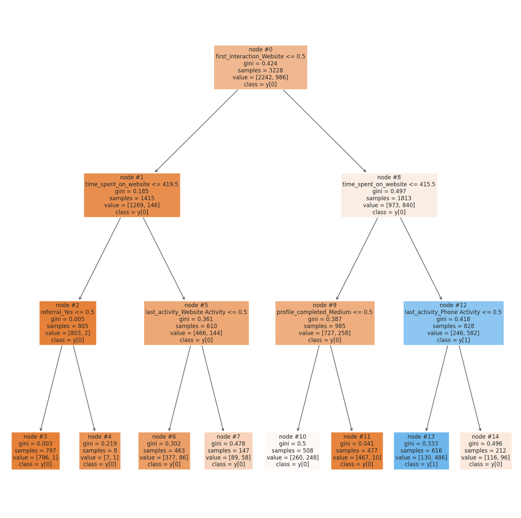

```python
features = list(X_train.columns)

# Building the model with max_depth=3
dt_clf_visualize = DecisionTreeClassifier(random_state = 1, max_depth=3)

# Fitting the model
dt_clf_visualize.fit(X_train, y_train)


plt.figure(figsize = (20, 20))
tree.plot_tree(dt_clf_visualize, feature_names = features, filled = True, fontsize = 12,
               node_ids = True, class_names = True)
plt.show()
```

**Let's visualize the decision tree and examine the tree's decision rules. Visualizing a Decision Tree can help you understand how the algorithm works and interpret its predictions. Visualizing the tree can help us to:**

- **Identify the root node:** The first node at the top of the tree is called the root node. It represents the entire dataset and is used to split the data into two or more homogeneous subsets. Here, the root node splits the lead data set according to their medium of first interaction (website or not).
- **Identify the internal nodes:** The nodes that are not leaf nodes are called internal nodes. They represent a decision or a test on a feature and are used to split the data into smaller subsets based on the feature value.
- **Identify the leaf nodes:** The nodes at the bottom of the tree are called leaf nodes. They represent the output or the class label of the data after going through all the splits in the tree.
- **Follow a path from the root to a leaf node:** To interpret a decision tree, we can follow a path from the root node to a leaf node. Along the path, we can see the tests performed on the features, and based on the test results, the data is split into smaller subsets. The order in which variables are considered to make a prediction is: website as first medium of interaction, time spent on the website, activity last recorded, referral and profile completeness.
- **Analyze the feature importance:** We can analyze the feature importance by looking at the splits in the tree. The features used to split the data at the top of the tree are the most important features, as they have the highest impact on the decision.
- **Analyze the class distribution:** We can analyze the class distribution at the leaf nodes to understand how the decision tree predicts the class labels. If the majority of the samples in a leaf node belong to a particular class, the decision tree predicts that class for the new data.
- **Explain the decision:** Finally, we can explain the decision made by the decision tree by summarizing the path taken from the root to the leaf node and the class label predicted at the leaf node. We can also explain the importance of the features used in the decision and how they influence the final prediction.

```python
print(tree.export_text(dt_clf_visualize, feature_names=X_train.columns.tolist(), show_weights=True))
```

```
|--- first_interaction_Website <= 0.50
|   |--- time_spent_on_website <= 419.50
|   |   |--- referral_Yes <= 0.50
|   |   |   |--- weights: [796.00, 1.00] class: 0
|   |   |--- referral_Yes >  0.50
|   |   |   |--- weights: [7.00, 1.00] class: 0
|   |--- time_spent_on_website >  419.50
|   |   |--- last_activity_Website Activity <= 0.50
|   |   |   |--- weights: [377.00, 86.00] class: 0
|   |   |--- last_activity_Website Activity >  0.50
|   |   |   |--- weights: [89.00, 58.00] class: 0
|--- first_interaction_Website >  0.50
|   |--- time_spent_on_website <= 415.50
|   |   |--- profile_completed_Medium <= 0.50
|   |   |   |--- weights: [260.00, 248.00] class: 0
|   |   |--- profile_completed_Medium >  0.50
|   |   |   |--- weights: [467.00, 10.00] class: 0
|   |--- time_spent_on_website >  415.50
|   |   |--- last_activity_Phone Activity <= 0.50
|   |   |   |--- weights: [130.00, 486.00] class: 1
|   |   |--- last_activity_Phone Activity >  0.50
|   |   |   |--- weights: [116.00, 96.00] class: 0
```

#### Bagging Classifier

**What is a Bagging Regressor?**

Bagging (short for Bootstrap Aggregating) is an ensemble learning technique that involves training multiple models on different subsets of the training data and then combining their predictions. The idea is to reduce variance and overfitting by averaging the predictions of many models.

A Bagging Regressor is a type of Bagging algorithm used for regression tasks. It involves training multiple regression models (e.g., Decision Trees) on different subsets of the training data and then combining their predictions by taking the average.

**How does a Bagging Regressor work?**

The Bagging Regressor works by generating multiple subsets of the training data by randomly selecting data points with replacement (i.e., allowing the same data point to be selected more than once in the same subset). Each subset is used to train a separate regression model, and the predictions of these models are combined by taking their average.

The idea behind this approach is that by training multiple models on different subsets of the data, we can reduce the variance and overfitting of the final model, while still maintaining the same bias as a single model trained on the entire dataset.

```python
# Bagging Classifier
bagging_estimator = BaggingClassifier(random_state = 1)

# Fitting the model
bagging_estimator.fit(X_train, y_train)

# Model Performance on the test data
bagging_estimator_perf_test = model_performance_classification(bagging_estimator, X_test, y_test)

bagging_estimator_perf_test
```

|  | Accuracy | Precision | Recall | F1 Score | Confusion Matrix |
| --- | --- | --- | --- | --- | --- |
| 0 | 0.851879 | 0.783537 | 0.657289 | 0.714882 | [[922, 71], [134, 257]] |

#### Random Forest

**What is a Random Forest?**

Random Forest is another ensemble learning technique that combines multiple Decision Trees to create a more robust and accurate model. Like Bagging, it involves training multiple models on different subsets of the training data, but with an additional twist: at each split in the tree, only a random subset of the available features is considered for splitting.

This helps to reduce the correlation between the trees in the forest and improves their overall accuracy.

**How does a Random Forest work?**

A Random Forest works by training multiple Decision Trees on different subsets of the training data, and then combining their predictions by taking their average. The key difference from Bagging is that at each split in the tree, only a random subset of the features is considered for splitting.

The algorithm works as follows:

- Generate multiple random subsets of the training data (with replacement).
- For each subset, train a Decision Tree on a random subset of the features.
- Make predictions for new data by averaging the predictions of all the trees in the forest.

The number of trees in the forest and the number of features considered at each split are hyperparameters that can be tuned to optimize the performance of the model.

The Random Forest algorithm doesn't have any specific equations, but it involves training multiple Decision Trees on different subsets of the training data with a random subset of the features considered at each split.

```python
# Random Forest Classifier
rf_clf = RandomForestClassifier(n_estimators = 100, random_state = 1)

# Fitting the model
rf_clf.fit(X_train, y_train)

# Model Performance on the test data
rf_clf_perf_test = model_performance_classification(rf_clf, X_test, y_test)

rf_clf_perf_test
```

|  | Accuracy | Precision | Recall | F1 Score | Confusion Matrix |
| --- | --- | --- | --- | --- | --- |
| 0 | 0.865607 | 0.804154 | 0.693095 | 0.744505 | [[927, 66], [120, 271]] |

#### AdaBoost

**What is Adaboost?**

Adaboost (short for Adaptive Boosting) is a type of boosting algorithm that combines multiple weak classifiers to create a stronger classifier. A weak classifier is a classifier that performs only slightly better than random guessing.

**How does Adaboost work?**

- Adaboost works by training multiple weak classifiers on different subsets of the training data, and then combining their predictions to make a final prediction. The algorithm works as follows:
- Assign equal weights to all the training examples.
- Train a weak classifier on a subset of the training data.
- Increase the weights of the misclassified examples.
- Train another weak classifier on the same subset of data but with the weights adjusted to give more importance to the misclassified examples.
- Repeat steps 3-4 for a specified number of iterations or until the error rate is sufficiently low.
- Combine the predictions of all the weak classifiers to make a final prediction.

The key idea behind Adaboost is that by giving more weight to the misclassified examples, the algorithm can focus on the examples that are more difficult to classify and improve its overall accuracy.

The Adaboost algorithm involves computing the weighted error rate of each weak classifier and using it to update the weights of the training examples. The equation for computing the weighted error rate is:

$$\large \epsilon_t = \frac{\sum_{i=1}^{N} w_{t,i} \cdot \mathrm{I\!I}(y_i \neq h_t(x_i))}{\sum_{i=1}^{N} w_{t,i}}$$

Here, $w_i$ is the weight of the $i_{th}$ training example, $y_i$ is the true label of the $i_{th}$ example, $h(x_i)$ is the prediction of the weak classifier for the $i_{th}$ example, and the sum is over all the training examples.

The weight of the weak classifier is then computed as:

$$\large \alpha_t = \frac{1}{2} \ln \left( \frac{1 - \epsilon_t}{\epsilon_t} \right)$$

where $\alpha_t$ is the weight of the $t_{th}$ weak learner in the final model, and $\epsilon_t$ is the weighted error of the $t_{th}$ weak learner.

Finally, the weights of the training examples are updated as follows:

$$\large w_i \gets w_i \exp(-\alpha y_i h(x_i))$$

Here, $exp()$ is the exponential function, $y_i$ is the true label of the $i_{th}$ example, $h(x_i)$ is the prediction of the weak classifier for the $i_{th}$ example, and the sum is over all the training examples.

```python
# AdaBoost Classifier
ada_clf = AdaBoostClassifier(random_state=1)

# Fitting the model
ada_clf.fit(X_train, y_train)

# Model Performance on the test data
ada_clf_perf_test = model_performance_classification(ada_clf, X_test, y_test)

ada_clf_perf_test
```

|  | Accuracy | Precision | Recall | F1 Score | Confusion Matrix |
| --- | --- | --- | --- | --- | --- |
| 0 | 0.830202 | 0.726744 | 0.639386 | 0.680272 | [[899, 94], [141, 250]] |

#### Gradient Boosting Classifier

**What is Gradient Boosting?**

Gradient Boosting is another boosting algorithm that combines multiple weak learners to create a strong learner. The difference between Adaboost and Gradient Boosting is that the former assigns different weights to different data points, while the latter fits the model to the residual errors of the previous model.

**How does Gradient Boosting work?**

Gradient Boosting works by sequentially adding weak learners to the model and updating the weights of the training examples based on the residual errors of the previous models. The algorithm works as follows:

Initialize the model with a constant value, such as the mean of the target variable.

For each weak learner:

- Train the weak learner on the training data.
- Compute the predictions of the weak learner.
- Compute the residual errors of the previous model by subtracting the predicted values from the actual values.
- Fit the weak learner to the residual errors.
- Update the weights of the training examples based on the fitted residual errors.
- Combine the predictions of all the weak learners to make a final prediction.

The key idea behind Gradient Boosting is that by fitting the model to the residual errors of the previous model, it can focus on the examples that were not well predicted by the previous model and improve its overall accuracy.

The Gradient Boosting algorithm involves computing the negative gradient of the loss function with respect to the predicted values and using it to update the model. The equation for computing the negative gradient is:

$$\large Negative\ Gradient = -\frac{\partial L(y_\text{true}, y_\text{pred})}{\partial y_\text{pred}}$$

Here, $y_{true}$ is the true label of the example, $y_{pred}$ is the predicted value of the model, and the partial derivatives are taken with respect to these variables.

The weight of the weak learner is then computed as:

$$\large \alpha = learning\ rate * negative\ gradient$$

Finally, the model is updated as:

$$\large model\ prediction = model\ prediction + alpha * weak\ learner\ prediction$$

Here, learning_rate is a hyperparameter that controls the step size of each update, weak learner prediction is the prediction of the weak learner for the example, and the sum is over all the weak learners.

```python
# Gradient Boosting Classifier
grad_clf = GradientBoostingClassifier(random_state=1)

# Fitting the model
grad_clf.fit(X_train, y_train)

# Model Performance on the test data
grad_clf_perf_test = model_performance_classification(grad_clf, X_test, y_test)

grad_clf_perf_test
```

|  | Accuracy | Precision | Recall | F1 Score | Confusion Matrix |
| --- | --- | --- | --- | --- | --- |
| 0 | 0.874277 | 0.802228 | 0.736573 | 0.768 | [[922, 71], [103, 288]] |

#### XGBoost Classifier

**What is XGBoost?**

XGBoost (short for Extreme Gradient Boosting) is a highly optimized implementation of the Gradient Boosting algorithm. It was developed by Tianqi Chen at the University of Washington and is widely used in data science competitions.

**How does XGBoost work?**

XGBoost works by sequentially adding weak learners to the model and updating the weights of the training examples based on the residual errors of the previous models. The algorithm is similar to Gradient Boosting, but includes several additional features to improve its performance:

**Regularization**:

XGBoost includes L1 and L2 regularization to prevent overfitting.

**Tree Pruning**: XGBoost includes a technique called "tree pruning" to remove irrelevant features and reduce the complexity of the model.

Weighted Quantile Sketch: XGBoost uses a weighted quantile sketch algorithm to speed up the computation of split points in the decision trees.

**Conclusions**:

The XGBoost algorithm involves computing the negative gradient of the loss function with respect to the predicted values and using it to update the model. The equation for computing the negative gradient is the same as in Gradient Boosting.

The weight of the weak learner is then computed as:

$$\large \alpha = learning\ rate * negative\ gradient + 0.5 * (L_1\ regularization + L_2\ regularization)$$

Finally, the model is updated.

```python
# XGBoost Regressor
xgb = XGBRFClassifier(random_state = 1)

# Fit the model
xgb.fit(X_train.to_numpy(), y_train)

# Model Performance on the test data
xgb_perf_test = model_performance_classification(xgb, X_test.to_numpy(), y_test)

xgb_perf_test
```

|  | Accuracy | Precision | Recall | F1 Score | Confusion Matrix |
| --- | --- | --- | --- | --- | --- |
| 0 | 0.878613 | 0.805479 | 0.751918 | 0.777778 | [[922, 71], [97, 294]] |

```python
xgb.predict(X_test)
```

```
array([0, 0, 1, ..., 0, 0, 0])
```

#### Hyper Parameter Tuning using Grid Search Cross Validation

```python
from sklearn.model_selection import GridSearchCV
from xgboost import XGBRFClassifier

# Define the parameter grid for grid search
param_grid = {
    'n_estimators': [2, 5],
    'max_depth': [1, 2],
    'learning_rate': [0.001, 0.01],
    'reg_lambda': [0.001, 0.01]
}

# Initialize XGBoost classifier
xgb = XGBRFClassifier(random_state=1)

# Initialize GridSearchCV
grid_search = GridSearchCV(estimator=xgb, param_grid=param_grid, cv=3, scoring='accuracy')

# Fit GridSearchCV to the training data
grid_search.fit(X_train, y_train)

# Get the best parameters and the best score
best_params = grid_search.best_params_
best_score = grid_search.best_score_

print("Best Parameters:", best_params)
print("Best Score:", best_score)

# Now, use the best parameters to train the XGBoost model
best_xgb = XGBRFClassifier(random_state=1, **best_params)
best_xgb.fit(X_train, y_train)

# Model Performance on the test data
xgb_perf_test = model_performance_classification(best_xgb, X_test, y_test)
print(xgb_perf_test)
```

```
Best Parameters: {'learning_rate': 0.001, 'max_depth': 1, 'n_estimators': 2, 'reg_lambda': 0.001}
Best Score: 0.69454770755886
   Accuracy  Precision  Recall  F1 Score      Confusion Matrix
0  0.717486        0.0     0.0       0.0  [[993, 0], [391, 0]]
```

#### **Models' Performance Comparison**

Comparing different machine learning models is an important step in the modeling process, as it allows us to understand the strengths and weaknesses of each model, and to choose the best one for a particular task.

```python
models_test_comp_df = pd.concat(
    [
        dt_clf_perf_test.T,
        bagging_estimator_perf_test.T,
        rf_clf_perf_test.T,
        ada_clf_perf_test.T,
        grad_clf_perf_test.T,
        xgb_perf_test.T
    ],
    axis = 1,
)

models_test_comp_df.columns = [
    "Decision tree Classifier",
    "Bagging Classifier",
    "Random Forest Classifier",
    "Ada Boost Classifier",
    "Gradient Boosting Classifier",
    "XG Boost Classifier"]

print("Test performance comparison:")

models_test_comp_df.T
```

```
Test performance comparison:
```

[output not shown]

### Deep Learning

We adress the issue of overfitting by combining the following techniques:

```
Average Accuracy across 2 folds: 0.4950433705080545
```

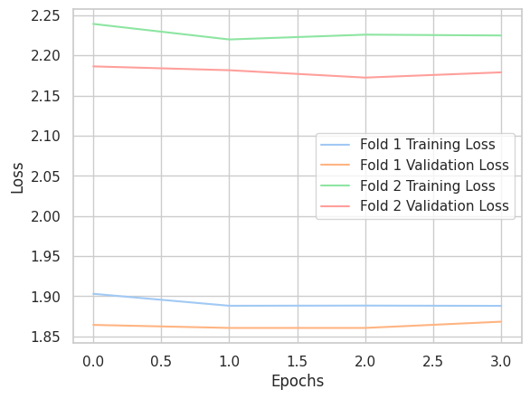

```python
# Set the number of folds
num_folds = 2

# Create a KFold object
kf = KFold(n_splits=num_folds, shuffle=True, random_state=42)

# Initialize a list to store accuracy values for each fold
accuracy_values = []
training_histories = []  # List to store training histories for each fold

# Iterate over folds
for train_index, val_index in kf.split(X_train):
    # Convert indices to lists
    train_index, val_index = list(train_index), list(val_index)

    # Split the data into training and validation sets for this fold
    X_fold_train, X_fold_val = X_train.iloc[train_index], X_train.iloc[val_index]
    y_fold_train, y_fold_val = y_train.iloc[train_index], y_train.iloc[val_index]


    # Build the MLP model for binary classification
    model = Sequential()
    model.add(Dropout(0.2))
    model.add(Dense(4, input_dim=X_train.shape[1], kernel_regularizer=l2(1),activation='relu'))
    model.add(BatchNormalization())

    # Output layer with sigmoid activation for binary classification
    model.add(Dense(1, activation='sigmoid'))

    # Compile the model for binary classification
    lr_schedule = schedules.ExponentialDecay(initial_learning_rate=1e-1, decay_steps=1, decay_rate=0.5)
    model.compile(optimizer=Adam(learning_rate=lr_schedule), loss='binary_crossentropy', metrics=['accuracy'])

    #early_stop = EarlyStopping(monitor='val_loss', patience=5, restore_best_weights=True)

    # Train the model and save the history
    history = model.fit(X_fold_train, y_fold_train, validation_data=(X_fold_val, y_fold_val),
                        epochs=4, batch_size=3, verbose=1)

    # Store the training history
    training_histories.append(history.history)

    # Predict on the validation set
    y_pred_val = model.predict(X_fold_val)
    y_pred_val_binary = (y_pred_val > 0.5).astype(int)

    # Evaluate the model on the validation set and store the accuracy
    accuracy_fold = accuracy_score(y_fold_val, y_pred_val_binary)
    accuracy_values.append(accuracy_fold)

# Calculate and print the average accuracy across all folds
average_accuracy = np.mean(accuracy_values)

print(f'Average Accuracy across {num_folds} folds: {average_accuracy}')

# Plot training and validation loss for each fold
for i, history in enumerate(training_histories):
    plt.plot(history['loss'], label=f'Fold {i+1} Training Loss')
    plt.plot(history['val_loss'], label=f'Fold {i+1} Validation Loss')

plt.xlabel('Epochs')
plt.ylabel('Loss')
plt.legend()
plt.show()
```

```python
# Predict on the training set
y_train_pred = model.predict(X_fold_train).flatten()
```

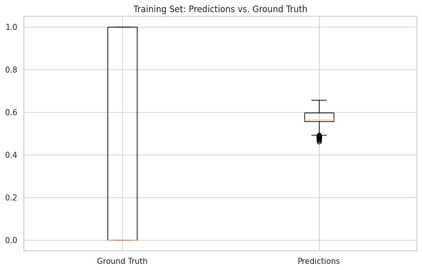

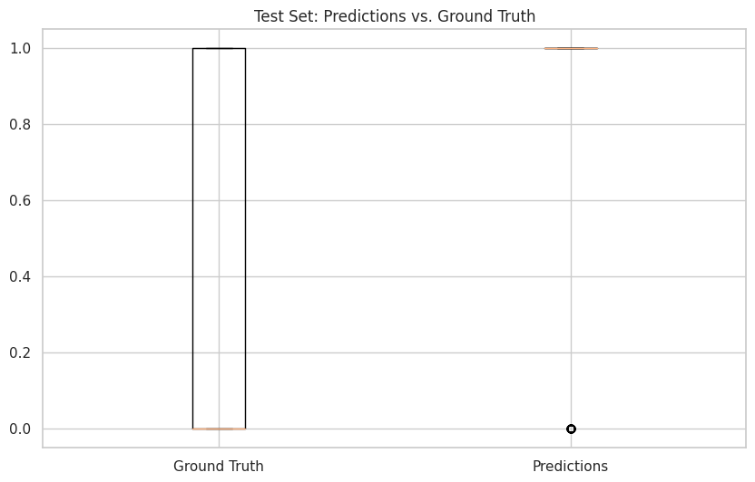

```python
# Plot predictions vs. ground truth for the training set
plt.figure(figsize=(10, 6))
plt.boxplot([y_fold_train, y_train_pred], labels=['Ground Truth', 'Predictions'])
plt.title('Training Set: Predictions vs. Ground Truth')
plt.show()


# Plot predictions vs. ground truth for the test set
plt.figure(figsize=(10, 6))
plt.boxplot([y_fold_val, y_pred_val_binary.ravel()], labels=['Ground Truth', 'Predictions'])
plt.title('Test Set: Predictions vs. Ground Truth')
plt.show()
```

```python
y_pred_val_binary.ravel()
```

```
array([1, 1, 1, ..., 1, 1, 1])
```

```python
X_fold_val
```

|  | age | website_visits | time_spent_on_website | page_views_per_visit | current_occupation_Student | current_occupation_Unemployed | first_interaction_Website | profile_completed_Low | profile_completed_Medium | last_activity_Phone Activity | last_activity_Website Activity | print_media_type1_Yes | print_media_type2_Yes | digital_media_Yes | educational_channels_Yes | referral_Yes |
| --- | --- | --- | --- | --- | --- | --- | --- | --- | --- | --- | --- | --- | --- | --- | --- | --- |
| 1 | 56 | 2 | 83 | 0.320 | 0 | 0 | 0 | 0 | 1 | 0 | 1 | 0 | 0 | 0 | 1 | 0 |
| 2 | 52 | 3 | 330 | 0.074 | 0 | 0 | 1 | 0 | 1 | 0 | 1 | 0 | 0 | 1 | 0 | 0 |
| 3 | 53 | 4 | 464 | 2.057 | 0 | 1 | 1 | 0 | 0 | 0 | 1 | 0 | 0 | 0 | 0 | 0 |
| 4 | 23 | 4 | 600 | 16.914 | 1 | 0 | 1 | 0 | 0 | 0 | 0 | 0 | 0 | 0 | 0 | 0 |
| 5 | 50 | 4 | 212 | 5.682 | 0 | 1 | 0 | 0 | 0 | 1 | 0 | 0 | 0 | 0 | 1 | 0 |
| ... | ... | ... | ... | ... | ... | ... | ... | ... | ... | ... | ... | ... | ... | ... | ... | ... |
| 4599 | 49 | 8 | 734 | 5.559 | 0 | 0 | 0 | 0 | 0 | 1 | 0 | 0 | 0 | 0 | 1 | 0 |
| 4600 | 60 | 2 | 40 | 0.122 | 0 | 1 | 0 | 0 | 0 | 1 | 0 | 1 | 1 | 0 | 0 | 0 |
| 4604 | 58 | 2 | 555 | 3.305 | 0 | 0 | 1 | 0 | 1 | 0 | 1 | 0 | 0 | 0 | 0 | 0 |
| 4608 | 55 | 8 | 2327 | 5.393 | 0 | 0 | 0 | 0 | 1 | 0 | 0 | 0 | 0 | 0 | 0 | 0 |
| 4611 | 55 | 4 | 2290 | 2.075 | 0 | 0 | 1 | 0 | 1 | 1 | 0 | 0 | 0 | 0 | 0 | 0 |

1614 rows × 16 columns